# Risk Factor Analysis

## Outcome Variable

**Outcome Variable:** stunted

## Predictor Variables

**Intervention Variable:** parity

**Adjustment Set:**

- arm
- W_mage
- meducyrs
- feducyrs
- hhwealth_quart
- W_mhtcm
- W_mwtkg
- W_mbmi
- vagbrth
- W_nrooms
- impsan
- delta_W_mage
- delta_meducyrs
- delta_feducyrs
- delta_hhwealth_quart
- delta_W_mhtcm
- delta_W_mwtkg
- delta_W_mbmi
- delta_vagbrth
- delta_W_nrooms
- delta_impsan

## Stratifying Variables

The analysis was stratified on these variable(s):

- agecat
- studyid
- country

## Data Summary

| agecat | studyid | country | parity | stunted | n_cell | n |
| --- | --- | --- | --- | --- | --- | --- |
| Birth | ki1000304b-SAS-CompFeed | INDIA | 1 | 0 | 238 | 1252 |
| Birth | ki1000304b-SAS-CompFeed | INDIA | 1 | 1 | 123 | 1252 |
| Birth | ki1000304b-SAS-CompFeed | INDIA | 2 | 0 | 215 | 1252 |
| Birth | ki1000304b-SAS-CompFeed | INDIA | 2 | 1 | 74 | 1252 |
| Birth | ki1000304b-SAS-CompFeed | INDIA | 3+ | 0 | 450 | 1252 |
| Birth | ki1000304b-SAS-CompFeed | INDIA | 3+ | 1 | 152 | 1252 |
| Birth | ki1017093b-PROVIDE | BANGLADESH | 1 | 0 | 186 | 539 |
| Birth | ki1017093b-PROVIDE | BANGLADESH | 1 | 1 | 20 | 539 |
| Birth | ki1017093b-PROVIDE | BANGLADESH | 2 | 0 | 167 | 539 |
| Birth | ki1017093b-PROVIDE | BANGLADESH | 2 | 1 | 16 | 539 |
| Birth | ki1017093b-PROVIDE | BANGLADESH | 3+ | 0 | 138 | 539 |
| Birth | ki1017093b-PROVIDE | BANGLADESH | 3+ | 1 | 12 | 539 |
| Birth | ki1101329-Keneba | GAMBIA | 1 | 0 | 140 | 1407 |
| Birth | ki1101329-Keneba | GAMBIA | 1 | 1 | 16 | 1407 |
| Birth | ki1101329-Keneba | GAMBIA | 2 | 0 | 138 | 1407 |
| Birth | ki1101329-Keneba | GAMBIA | 2 | 1 | 8 | 1407 |
| Birth | ki1101329-Keneba | GAMBIA | 3+ | 0 | 1054 | 1407 |
| Birth | ki1101329-Keneba | GAMBIA | 3+ | 1 | 51 | 1407 |
| Birth | ki1113344-GMS-Nepal | NEPAL | 1 | 0 | 158 | 696 |
| Birth | ki1113344-GMS-Nepal | NEPAL | 1 | 1 | 53 | 696 |
| Birth | ki1113344-GMS-Nepal | NEPAL | 2 | 0 | 152 | 696 |
| Birth | ki1113344-GMS-Nepal | NEPAL | 2 | 1 | 28 | 696 |
| Birth | ki1113344-GMS-Nepal | NEPAL | 3+ | 0 | 264 | 696 |
| Birth | ki1113344-GMS-Nepal | NEPAL | 3+ | 1 | 41 | 696 |
| Birth | ki1126311-ZVITAMBO | ZIMBABWE | 1 | 0 | 5349 | 13874 |
| Birth | ki1126311-ZVITAMBO | ZIMBABWE | 1 | 1 | 640 | 13874 |
| Birth | ki1126311-ZVITAMBO | ZIMBABWE | 2 | 0 | 3735 | 13874 |
| Birth | ki1126311-ZVITAMBO | ZIMBABWE | 2 | 1 | 409 | 13874 |
| Birth | ki1126311-ZVITAMBO | ZIMBABWE | 3+ | 0 | 3356 | 13874 |
| Birth | ki1126311-ZVITAMBO | ZIMBABWE | 3+ | 1 | 385 | 13874 |

[output cut: 144 more lines]

The following strata were considered:

- agecat: 24 months, studyid: ki1017093b-PROVIDE, country: BANGLADESH
- agecat: 24 months, studyid: ki1066203-TanzaniaChild2, country: TANZANIA, UNITED REPUBLIC OF
- agecat: 24 months, studyid: ki1101329-Keneba, country: GAMBIA
- agecat: 24 months, studyid: ki1113344-GMS-Nepal, country: NEPAL
- agecat: 24 months, studyid: ki1126311-ZVITAMBO, country: ZIMBABWE
- agecat: 24 months, studyid: ki1135781-COHORTS, country: GUATEMALA
- agecat: 24 months, studyid: ki1135781-COHORTS, country: INDIA
- agecat: 24 months, studyid: ki1135781-COHORTS, country: PHILIPPINES
- agecat: 24 months, studyid: kiGH5241-JiVitA-3, country: BANGLADESH
- agecat: 6 months, studyid: ki1000304b-SAS-CompFeed, country: INDIA
- agecat: 6 months, studyid: ki1000304b-SAS-FoodSuppl, country: INDIA
- agecat: 6 months, studyid: ki1017093b-PROVIDE, country: BANGLADESH
- agecat: 6 months, studyid: ki1066203-TanzaniaChild2, country: TANZANIA, UNITED REPUBLIC OF
- agecat: 6 months, studyid: ki1101329-Keneba, country: GAMBIA
- agecat: 6 months, studyid: ki1113344-GMS-Nepal, country: NEPAL
- agecat: 6 months, studyid: ki1126311-ZVITAMBO, country: ZIMBABWE
- agecat: 6 months, studyid: ki1135781-COHORTS, country: GUATEMALA
- agecat: 6 months, studyid: ki1135781-COHORTS, country: INDIA
- agecat: 6 months, studyid: ki1135781-COHORTS, country: PHILIPPINES
- agecat: 6 months, studyid: kiGH5241-JiVitA-3, country: BANGLADESH
- agecat: Birth, studyid: ki1000304b-SAS-CompFeed, country: INDIA
- agecat: Birth, studyid: ki1017093b-PROVIDE, country: BANGLADESH
- agecat: Birth, studyid: ki1101329-Keneba, country: GAMBIA
- agecat: Birth, studyid: ki1113344-GMS-Nepal, country: NEPAL
- agecat: Birth, studyid: ki1126311-ZVITAMBO, country: ZIMBABWE
- agecat: Birth, studyid: ki1135781-COHORTS, country: GUATEMALA
- agecat: Birth, studyid: ki1135781-COHORTS, country: INDIA
- agecat: Birth, studyid: ki1135781-COHORTS, country: PHILIPPINES
- agecat: Birth, studyid: kiGH5241-JiVitA-3, country: BANGLADESH

### Dropped Strata

Some strata were dropped due to rare outcomes:

- agecat: 6 months, studyid: ki1000304b-SAS-FoodSuppl, country: INDIA
- agecat: 24 months, studyid: ki1066203-TanzaniaChild2, country: TANZANIA, UNITED REPUBLIC OF

## Methods Detail

We’re interested in the causal parameters $E[Y_a]$ for all values of $a \in \mathcal{A}$. These parameters represent the mean outcome if, possibly contrary to fact, we intervened to set all units to have $A=a$. Under the randomization and positivity assumptions, these are identified by the statistical parameters $\psi_a=E_W[E_{Y|A,W}(Y|A=a,W)]$. In addition, we’re interested in the mean of $Y$, $E[Y]$ under no intervention (the observed mean). We will estimate these parameters by using SuperLearner to fit the relevant likelihood factors – $E_{Y|A,W}(Y|A=a,W)$ and $p(A=a|W)$, and then updating our likelihood fit using a joint TMLE.

For unadjusted analyses ($W=\{\}$), initial likelihoods were estimated using Lrnr_glm to estimate the simple $E(Y|A)$ and Lrnr_mean to estimate $p(A)$. For adjusted analyses, a small library containing Lrnr_glmnet, Lrnr_xgboost, and Lrnr_mean was used.

Having estimated these parameters, we will then use the delta method to estimate relative risks and attributable risks relative to a prespecified baseline level of $A$.

# Results Detail

## Results Plots

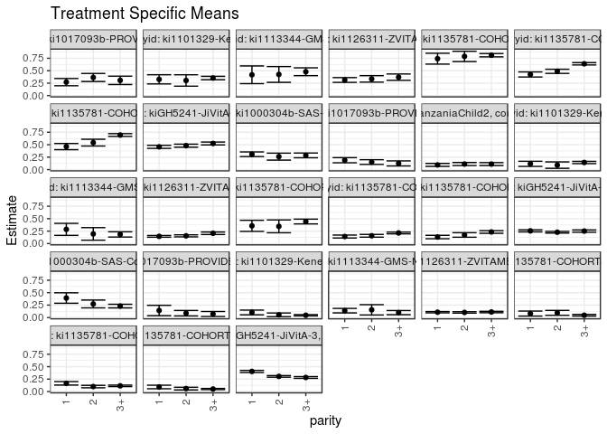

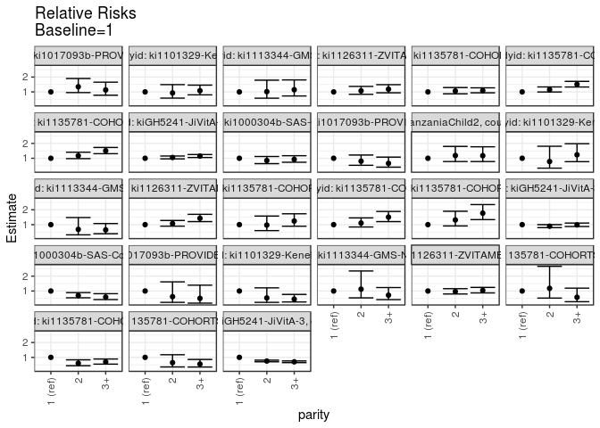

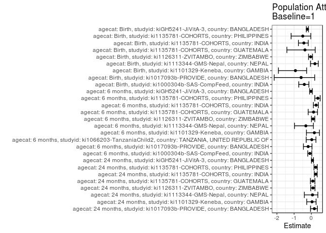

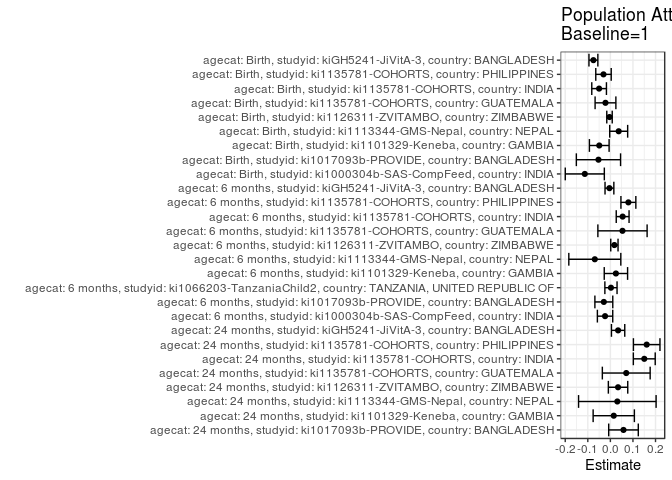

## Results Table

### Parameter: TSM

| agecat | studyid | country | intervention_level | baseline_level | estimate | ci_lower | ci_upper |
| --- | --- | --- | --- | --- | --- | --- | --- |
| Birth | ki1000304b-SAS-CompFeed | INDIA | 1 | NA | 0.3920634 | 0.2870980 | 0.4970288 |
| Birth | ki1000304b-SAS-CompFeed | INDIA | 2 | NA | 0.2729279 | 0.1944311 | 0.3514246 |
| Birth | ki1000304b-SAS-CompFeed | INDIA | 3+ | NA | 0.2309071 | 0.1941253 | 0.2676889 |
| Birth | ki1017093b-PROVIDE | BANGLADESH | 1 | NA | 0.1418472 | 0.0376843 | 0.2460100 |
| Birth | ki1017093b-PROVIDE | BANGLADESH | 2 | NA | 0.0875746 | 0.0328624 | 0.1422868 |
| Birth | ki1017093b-PROVIDE | BANGLADESH | 3+ | NA | 0.0715800 | 0.0214810 | 0.1216789 |
| Birth | ki1101329-Keneba | GAMBIA | 1 | NA | 0.1025641 | 0.0549386 | 0.1501896 |
| Birth | ki1101329-Keneba | GAMBIA | 2 | NA | 0.0547945 | 0.0178664 | 0.0917227 |
| Birth | ki1101329-Keneba | GAMBIA | 3+ | NA | 0.0461538 | 0.0337783 | 0.0585294 |
| Birth | ki1113344-GMS-Nepal | NEPAL | 1 | NA | 0.1384574 | 0.0934002 | 0.1835147 |
| Birth | ki1113344-GMS-Nepal | NEPAL | 2 | NA | 0.1554716 | 0.0520338 | 0.2589094 |
| Birth | ki1113344-GMS-Nepal | NEPAL | 3+ | NA | 0.0994835 | 0.0572207 | 0.1417462 |
| Birth | ki1126311-ZVITAMBO | ZIMBABWE | 1 | NA | 0.1072407 | 0.0941350 | 0.1203464 |
| Birth | ki1126311-ZVITAMBO | ZIMBABWE | 2 | NA | 0.1030623 | 0.0889035 | 0.1172212 |
| Birth | ki1126311-ZVITAMBO | ZIMBABWE | 3+ | NA | 0.1115290 | 0.0973064 | 0.1257516 |
| Birth | ki1135781-COHORTS | GUATEMALA | 1 | NA | 0.0803571 | 0.0299820 | 0.1307322 |
| Birth | ki1135781-COHORTS | GUATEMALA | 2 | NA | 0.0948905 | 0.0457879 | 0.1439931 |
| Birth | ki1135781-COHORTS | GUATEMALA | 3+ | NA | 0.0464345 | 0.0296294 | 0.0632396 |
| Birth | ki1135781-COHORTS | INDIA | 1 | NA | 0.1651657 | 0.1305233 | 0.1998082 |
| Birth | ki1135781-COHORTS | INDIA | 2 | NA | 0.0999719 | 0.0756025 | 0.1243412 |
| Birth | ki1135781-COHORTS | INDIA | 3+ | NA | 0.1148897 | 0.1001802 | 0.1295991 |
| Birth | ki1135781-COHORTS | PHILIPPINES | 1 | NA | 0.0918122 | 0.0561540 | 0.1274705 |
| Birth | ki1135781-COHORTS | PHILIPPINES | 2 | NA | 0.0593652 | 0.0322440 | 0.0864863 |
| Birth | ki1135781-COHORTS | PHILIPPINES | 3+ | NA | 0.0504027 | 0.0390748 | 0.0617307 |
| Birth | kiGH5241-JiVitA-3 | BANGLADESH | 1 | NA | 0.4041549 | 0.3831326 | 0.4251773 |
| Birth | kiGH5241-JiVitA-3 | BANGLADESH | 2 | NA | 0.3045137 | 0.2882219 | 0.3208056 |
| Birth | kiGH5241-JiVitA-3 | BANGLADESH | 3+ | NA | 0.2829368 | 0.2651647 | 0.3007089 |
| 6 months | ki1000304b-SAS-CompFeed | INDIA | 1 | NA | 0.3080031 | 0.2615107 | 0.3544955 |
| 6 months | ki1000304b-SAS-CompFeed | INDIA | 2 | NA | 0.2605464 | 0.1906451 | 0.3304476 |
| 6 months | ki1000304b-SAS-CompFeed | INDIA | 3+ | NA | 0.2848648 | 0.2369681 | 0.3327615 |

[output cut: 51 more lines]

### Parameter: E(Y)

| agecat | studyid | country | intervention_level | baseline_level | estimate | ci_lower | ci_upper |
| --- | --- | --- | --- | --- | --- | --- | --- |
| Birth | ki1000304b-SAS-CompFeed | INDIA | NA | NA | 0.2787540 | 0.2475949 | 0.3099131 |
| Birth | ki1017093b-PROVIDE | BANGLADESH | NA | NA | 0.0890538 | 0.0649864 | 0.1131212 |
| Birth | ki1101329-Keneba | GAMBIA | NA | NA | 0.0533049 | 0.0415629 | 0.0650470 |
| Birth | ki1113344-GMS-Nepal | NEPAL | NA | NA | 0.1752874 | 0.1470202 | 0.2035545 |
| Birth | ki1126311-ZVITAMBO | ZIMBABWE | NA | NA | 0.1033588 | 0.0982930 | 0.1084246 |
| Birth | ki1135781-COHORTS | GUATEMALA | NA | NA | 0.0586854 | 0.0428942 | 0.0744767 |
| Birth | ki1135781-COHORTS | INDIA | NA | NA | 0.1152353 | 0.1054865 | 0.1249842 |
| Birth | ki1135781-COHORTS | PHILIPPINES | NA | NA | 0.0613115 | 0.0527962 | 0.0698268 |
| Birth | kiGH5241-JiVitA-3 | BANGLADESH | NA | NA | 0.3289690 | 0.3216017 | 0.3363364 |
| 6 months | ki1000304b-SAS-CompFeed | INDIA | NA | NA | 0.2844311 | 0.2666491 | 0.3022132 |
| 6 months | ki1017093b-PROVIDE | BANGLADESH | NA | NA | 0.1589404 | 0.1297581 | 0.1881227 |
| 6 months | ki1066203-TanzaniaChild2 | TANZANIA, UNITED REPUBLIC OF | NA | NA | 0.0967419 | 0.0837671 | 0.1097166 |
| 6 months | ki1101329-Keneba | GAMBIA | NA | NA | 0.1398644 | 0.1229849 | 0.1567440 |
| 6 months | ki1113344-GMS-Nepal | NEPAL | NA | NA | 0.2163121 | 0.1823021 | 0.2503220 |
| 6 months | ki1126311-ZVITAMBO | ZIMBABWE | NA | NA | 0.1628980 | 0.1551237 | 0.1706723 |
| 6 months | ki1135781-COHORTS | GUATEMALA | NA | NA | 0.4099896 | 0.3788775 | 0.4411017 |
| 6 months | ki1135781-COHORTS | INDIA | NA | NA | 0.1957586 | 0.1838852 | 0.2076319 |
| 6 months | ki1135781-COHORTS | PHILIPPINES | NA | NA | 0.2112260 | 0.1958496 | 0.2266024 |
| 6 months | kiGH5241-JiVitA-3 | BANGLADESH | NA | NA | 0.2513830 | 0.2432594 | 0.2595066 |
| 24 months | ki1017093b-PROVIDE | BANGLADESH | NA | NA | 0.3287197 | 0.2903909 | 0.3670485 |
| 24 months | ki1101329-Keneba | GAMBIA | NA | NA | 0.3415698 | 0.3165034 | 0.3666361 |
| 24 months | ki1113344-GMS-Nepal | NEPAL | NA | NA | 0.4487705 | 0.4045970 | 0.4929440 |
| 24 months | ki1126311-ZVITAMBO | ZIMBABWE | NA | NA | 0.3471629 | 0.3241082 | 0.3702176 |
| 24 months | ki1135781-COHORTS | GUATEMALA | NA | NA | 0.8120301 | 0.7885439 | 0.8355162 |
| 24 months | ki1135781-COHORTS | INDIA | NA | NA | 0.5742604 | 0.5575886 | 0.5909321 |
| 24 months | ki1135781-COHORTS | PHILIPPINES | NA | NA | 0.6229039 | 0.6036892 | 0.6421186 |
| 24 months | kiGH5241-JiVitA-3 | BANGLADESH | NA | NA | 0.4910797 | 0.4779658 | 0.5041936 |

### Parameter: RR

| agecat | studyid | country | intervention_level | baseline_level | estimate | ci_lower | ci_upper |
| --- | --- | --- | --- | --- | --- | --- | --- |
| Birth | ki1000304b-SAS-CompFeed | INDIA | 1 | 1 | 1.0000000 | 1.0000000 | 1.0000000 |
| Birth | ki1000304b-SAS-CompFeed | INDIA | 2 | 1 | 0.6961319 | 0.5439144 | 0.8909484 |
| Birth | ki1000304b-SAS-CompFeed | INDIA | 3+ | 1 | 0.5889534 | 0.4233415 | 0.8193530 |
| Birth | ki1017093b-PROVIDE | BANGLADESH | 1 | 1 | 1.0000000 | 1.0000000 | 1.0000000 |
| Birth | ki1017093b-PROVIDE | BANGLADESH | 2 | 1 | 0.6173873 | 0.2358593 | 1.6160780 |
| Birth | ki1017093b-PROVIDE | BANGLADESH | 3+ | 1 | 0.5046274 | 0.1829649 | 1.3917906 |
| Birth | ki1101329-Keneba | GAMBIA | 1 | 1 | 1.0000000 | 1.0000000 | 1.0000000 |
| Birth | ki1101329-Keneba | GAMBIA | 2 | 1 | 0.5342466 | 0.2356709 | 1.2110933 |
| Birth | ki1101329-Keneba | GAMBIA | 3+ | 1 | 0.4500000 | 0.2632335 | 0.7692791 |
| Birth | ki1113344-GMS-Nepal | NEPAL | 1 | 1 | 1.0000000 | 1.0000000 | 1.0000000 |
| Birth | ki1113344-GMS-Nepal | NEPAL | 2 | 1 | 1.1228836 | 0.5367759 | 2.3489645 |
| Birth | ki1113344-GMS-Nepal | NEPAL | 3+ | 1 | 0.7185129 | 0.4189976 | 1.2321331 |
| Birth | ki1126311-ZVITAMBO | ZIMBABWE | 1 | 1 | 1.0000000 | 1.0000000 | 1.0000000 |
| Birth | ki1126311-ZVITAMBO | ZIMBABWE | 2 | 1 | 0.9610375 | 0.7997050 | 1.1549172 |
| Birth | ki1126311-ZVITAMBO | ZIMBABWE | 3+ | 1 | 1.0399876 | 0.8716662 | 1.2408125 |
| Birth | ki1135781-COHORTS | GUATEMALA | 1 | 1 | 1.0000000 | 1.0000000 | 1.0000000 |
| Birth | ki1135781-COHORTS | GUATEMALA | 2 | 1 | 1.1808597 | 0.5238079 | 2.6621012 |
| Birth | ki1135781-COHORTS | GUATEMALA | 3+ | 1 | 0.5778515 | 0.2801877 | 1.1917454 |
| Birth | ki1135781-COHORTS | INDIA | 1 | 1 | 1.0000000 | 1.0000000 | 1.0000000 |
| Birth | ki1135781-COHORTS | INDIA | 2 | 1 | 0.6052821 | 0.4389509 | 0.8346410 |
| Birth | ki1135781-COHORTS | INDIA | 3+ | 1 | 0.6956025 | 0.5441503 | 0.8892082 |
| Birth | ki1135781-COHORTS | PHILIPPINES | 1 | 1 | 1.0000000 | 1.0000000 | 1.0000000 |
| Birth | ki1135781-COHORTS | PHILIPPINES | 2 | 1 | 0.6465933 | 0.3550417 | 1.1775600 |
| Birth | ki1135781-COHORTS | PHILIPPINES | 3+ | 1 | 0.5489762 | 0.3507003 | 0.8593514 |
| Birth | kiGH5241-JiVitA-3 | BANGLADESH | 1 | 1 | 1.0000000 | 1.0000000 | 1.0000000 |
| Birth | kiGH5241-JiVitA-3 | BANGLADESH | 2 | 1 | 0.7534579 | 0.7001354 | 0.8108414 |
| Birth | kiGH5241-JiVitA-3 | BANGLADESH | 3+ | 1 | 0.7000701 | 0.6459850 | 0.7586834 |
| 6 months | ki1000304b-SAS-CompFeed | INDIA | 1 | 1 | 1.0000000 | 1.0000000 | 1.0000000 |
| 6 months | ki1000304b-SAS-CompFeed | INDIA | 2 | 1 | 0.8459211 | 0.6384000 | 1.1209000 |
| 6 months | ki1000304b-SAS-CompFeed | INDIA | 3+ | 1 | 0.9248762 | 0.7303728 | 1.1711771 |

[output cut: 51 more lines]

### Parameter: PAR

| agecat | studyid | country | intervention_level | baseline_level | estimate | ci_lower | ci_upper |
| --- | --- | --- | --- | --- | --- | --- | --- |
| Birth | ki1000304b-SAS-CompFeed | INDIA | 1 | NA | -0.1133094 | -0.1998508 | -0.0267680 |
| Birth | ki1017093b-PROVIDE | BANGLADESH | 1 | NA | -0.0527934 | -0.1507782 | 0.0451915 |
| Birth | ki1101329-Keneba | GAMBIA | 1 | NA | -0.0492592 | -0.0928837 | -0.0056347 |
| Birth | ki1113344-GMS-Nepal | NEPAL | 1 | NA | 0.0368299 | -0.0029471 | 0.0766069 |
| Birth | ki1126311-ZVITAMBO | ZIMBABWE | 1 | NA | -0.0038819 | -0.0159372 | 0.0081734 |
| Birth | ki1135781-COHORTS | GUATEMALA | 1 | NA | -0.0216717 | -0.0677134 | 0.0243700 |
| Birth | ki1135781-COHORTS | INDIA | 1 | NA | -0.0499304 | -0.0824277 | -0.0174331 |
| Birth | ki1135781-COHORTS | PHILIPPINES | 1 | NA | -0.0305008 | -0.0647023 | 0.0037008 |
| Birth | kiGH5241-JiVitA-3 | BANGLADESH | 1 | NA | -0.0751859 | -0.0949081 | -0.0554637 |
| 6 months | ki1000304b-SAS-CompFeed | INDIA | 1 | NA | -0.0235720 | -0.0575971 | 0.0104531 |
| 6 months | ki1017093b-PROVIDE | BANGLADESH | 1 | NA | -0.0289949 | -0.0686167 | 0.0106270 |
| 6 months | ki1066203-TanzaniaChild2 | TANZANIA, UNITED REPUBLIC OF | 1 | NA | 0.0025847 | -0.0244022 | 0.0295715 |
| 6 months | ki1101329-Keneba | GAMBIA | 1 | NA | 0.0245516 | -0.0271537 | 0.0762568 |
| 6 months | ki1113344-GMS-Nepal | NEPAL | 1 | NA | -0.0689575 | -0.1841564 | 0.0462414 |
| 6 months | ki1126311-ZVITAMBO | ZIMBABWE | 1 | NA | 0.0178210 | 0.0016736 | 0.0339684 |
| 6 months | ki1135781-COHORTS | GUATEMALA | 1 | NA | 0.0536863 | -0.0553823 | 0.1627550 |
| 6 months | ki1135781-COHORTS | INDIA | 1 | NA | 0.0543812 | 0.0259833 | 0.0827792 |
| 6 months | ki1135781-COHORTS | PHILIPPINES | 1 | NA | 0.0797870 | 0.0467459 | 0.1128281 |
| 6 months | kiGH5241-JiVitA-3 | BANGLADESH | 1 | NA | -0.0041597 | -0.0236925 | 0.0153730 |
| 24 months | ki1017093b-PROVIDE | BANGLADESH | 1 | NA | 0.0581475 | -0.0074039 | 0.1236988 |
| 24 months | ki1101329-Keneba | GAMBIA | 1 | NA | 0.0149698 | -0.0763810 | 0.1063206 |
| 24 months | ki1113344-GMS-Nepal | NEPAL | 1 | NA | 0.0307939 | -0.1409660 | 0.2025538 |
| 24 months | ki1126311-ZVITAMBO | ZIMBABWE | 1 | NA | 0.0339939 | -0.0089700 | 0.0769579 |
| 24 months | ki1135781-COHORTS | GUATEMALA | 1 | NA | 0.0703341 | -0.0356015 | 0.1762696 |
| 24 months | ki1135781-COHORTS | INDIA | 1 | NA | 0.1502264 | 0.1017383 | 0.1987146 |
| 24 months | ki1135781-COHORTS | PHILIPPINES | 1 | NA | 0.1608891 | 0.1020814 | 0.2196967 |
| 24 months | kiGH5241-JiVitA-3 | BANGLADESH | 1 | NA | 0.0342352 | 0.0047675 | 0.0637030 |

### Parameter: PAF

| agecat | studyid | country | intervention_level | baseline_level | estimate | ci_lower | ci_upper |
| --- | --- | --- | --- | --- | --- | --- | --- |
| Birth | ki1000304b-SAS-CompFeed | INDIA | 1 | NA | -0.4064854 | -0.7305991 | -0.1430731 |
| Birth | ki1017093b-PROVIDE | BANGLADESH | 1 | NA | -0.5928255 | -2.1559658 | 0.1960962 |
| Birth | ki1101329-Keneba | GAMBIA | 1 | NA | -0.9241025 | -1.9135260 | -0.2706839 |
| Birth | ki1113344-GMS-Nepal | NEPAL | 1 | NA | 0.2101116 | -0.0490734 | 0.4052622 |
| Birth | ki1126311-ZVITAMBO | ZIMBABWE | 1 | NA | -0.0375574 | -0.1610046 | 0.0727639 |
| Birth | ki1135781-COHORTS | GUATEMALA | 1 | NA | -0.3692857 | -1.4191803 | 0.2249675 |
| Birth | ki1135781-COHORTS | INDIA | 1 | NA | -0.4332908 | -0.7444053 | -0.1776635 |
| Birth | ki1135781-COHORTS | PHILIPPINES | 1 | NA | -0.4974722 | -1.1745789 | -0.0311987 |
| Birth | kiGH5241-JiVitA-3 | BANGLADESH | 1 | NA | -0.2285501 | -0.2902416 | -0.1698082 |
| 6 months | ki1000304b-SAS-CompFeed | INDIA | 1 | NA | -0.0828742 | -0.2061602 | 0.0278103 |
| 6 months | ki1017093b-PROVIDE | BANGLADESH | 1 | NA | -0.1824260 | -0.4585675 | 0.0414354 |
| 6 months | ki1066203-TanzaniaChild2 | TANZANIA, UNITED REPUBLIC OF | 1 | NA | 0.0267174 | -0.2962630 | 0.2692230 |
| 6 months | ki1101329-Keneba | GAMBIA | 1 | NA | 0.1755382 | -0.2854861 | 0.4712216 |
| 6 months | ki1113344-GMS-Nepal | NEPAL | 1 | NA | -0.3187873 | -0.9769659 | 0.1202681 |
| 6 months | ki1126311-ZVITAMBO | ZIMBABWE | 1 | NA | 0.1093997 | 0.0046451 | 0.2031296 |
| 6 months | ki1135781-COHORTS | GUATEMALA | 1 | NA | 0.1309456 | -0.1798063 | 0.3598478 |
| 6 months | ki1135781-COHORTS | INDIA | 1 | NA | 0.2777974 | 0.1181842 | 0.4085199 |
| 6 months | ki1135781-COHORTS | PHILIPPINES | 1 | NA | 0.3777327 | 0.2026535 | 0.5143685 |
| 6 months | kiGH5241-JiVitA-3 | BANGLADESH | 1 | NA | -0.0165474 | -0.0973172 | 0.0582773 |
| 24 months | ki1017093b-PROVIDE | BANGLADESH | 1 | NA | 0.1768907 | -0.0474652 | 0.3531920 |
| 24 months | ki1101329-Keneba | GAMBIA | 1 | NA | 0.0438265 | -0.2643531 | 0.2768889 |
| 24 months | ki1113344-GMS-Nepal | NEPAL | 1 | NA | 0.0686184 | -0.4049226 | 0.3825485 |
| 24 months | ki1126311-ZVITAMBO | ZIMBABWE | 1 | NA | 0.0979192 | -0.0346292 | 0.2134866 |
| 24 months | ki1135781-COHORTS | GUATEMALA | 1 | NA | 0.0866151 | -0.0537224 | 0.2082621 |
| 24 months | ki1135781-COHORTS | INDIA | 1 | NA | 0.2615998 | 0.1719049 | 0.3415795 |
| 24 months | ki1135781-COHORTS | PHILIPPINES | 1 | NA | 0.2582888 | 0.1572507 | 0.3472133 |
| 24 months | kiGH5241-JiVitA-3 | BANGLADESH | 1 | NA | 0.0697142 | 0.0078934 | 0.1276827 |